# Mapping Myanmar’s Political Violence

ISSS626 Take-home Exercise 2 — Executive Summary

Jin Jiaying

2026 October

## Contents

1. Study overview
2. Data preparation and quality
3. Analytical framework
4. Cross-sectional clusters: LISA and Gi*
5. EHSA: spatio-temporal patterns
6. Why temporal interpretation matters
7. Selecting the SKATER partition
8. Connected regional groups
9. Cluster temporal profiles
10. Integrated insights and limitations

**Note:** This executive summary focuses on the analytical story and visual evidence. Complete code, diagnostics, references and the AI tool declaration are provided in the companion Technical Report.

## 1. Study Overview

**Central question**

**Where are political violence events concentrated across Myanmar townships, how do the patterns change over time, and which geographically connected regions share similar histories?**

**Study scope**

- **Location:** Myanmar’s township (ADM3) boundaries.
- **Time:** January 2021–September 2025.
- **Measure:** recorded political violence **event frequency**, not severity.

**Analytical questions**

**Where?** Local Moran’s I (LISA).

**How concentrated?** Getis-Ord Gi*.

**How does concentration change?** EHSA.

**Which regions have similar histories?** SKATER.

## 2. Data Preparation and Quality

**Input and event definition**

- **ACLED:** 54,000 eligible records across Battles, Explosions/Remote violence and Violence against civilians; **53,992** spatially matched.
- **MIMU:** complete township boundary dataset.
- **57 monthly periods:** zero-event township-months retained.

**Key data quality findings**

- **330** townships retained after repairing nested GeometryCollections.
- **327** townships included in neighbour-based analysis.
- **3** townships without contiguous neighbours retained on maps separately.
- **18,639** complete township-month observations in EHSA.

**Workflow:** ACLED event screening → MIMU boundary repair → spatial assignment → complete monthly panel → spatial and spatio-temporal analysis.

## 3. Analytical Framework

**LISA — local spatial association**

High–High, Low–Low and spatial outliers.

**Gi* — local concentration**

Statistically significant hot and cold spots.

**EHSA — temporal classification**

Sporadic, oscillating and persistent spatial patterns using monthly data.

**SKATER — connected regional groups**

Contiguous townships with similar yearly violence profiles and event persistence.

**Interpretation boundary:** LISA/Gi* significance, EHSA temporal classification and SKATER cluster membership describe different properties. They are not interchangeable risk scores.

## 4. LISA and Gi* — Strong Spatial Agreement

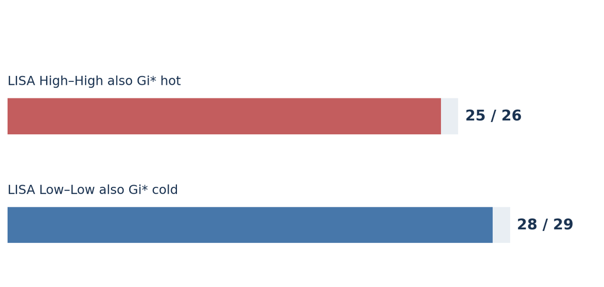

*Derived from TR §10.4 comparison table; an agreement chart, not a spatial map.*

**Main findings**

- **25 of 26** LISA High–High townships are Gi* hot spots.
- **28 of 29** LISA Low–Low townships are Gi* cold spots.
- Overall Gi*: **27 hot**, **32 cold**.

**Spatial coverage**

Three townships without contiguous neighbours were not tested, but remain on the reference maps.

## 5. EHSA — Monthly Spatial Patterns

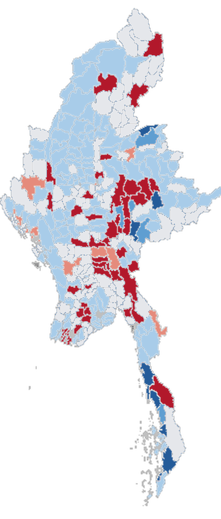

**What the map shows**

The **monthly EHSA classifications** distinguish sporadic, oscillating and persistent local spatial patterns. Colours follow TR §11.4 (red = hot; blue = cold; grey = other).

**Categories present in the results**

**Hot spots:** ■ sporadic · ■ oscillating.  
**Cold spots:** ■ sporadic · ■ oscillating · ■ persistent.  
**Other:** ■ no contiguous neighbour · ■ no pattern detected.

**Caution:** A coldspot category describes a relative statistical pattern, not an area that is necessarily safe.

## 6. Why Aggregate and Monthly Patterns Differ

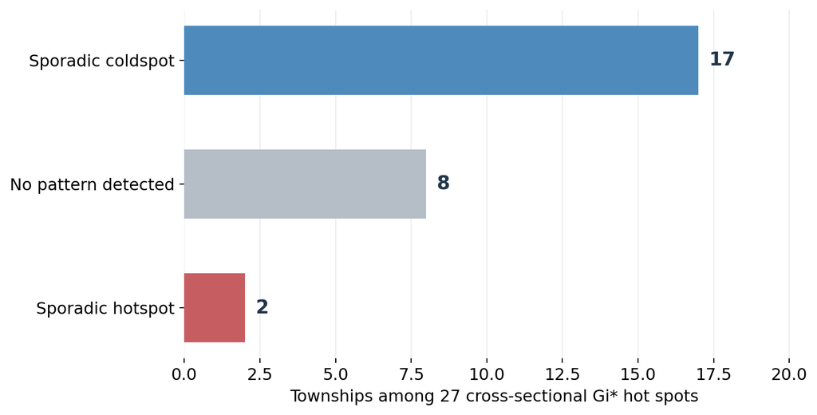

**Unexpected result**

Among **27** Gi* hot spots:

- **17** sporadic EHSA coldspots
- **8** no pattern detected
- **2** sporadic EHSA hotspots

**Interpretation**

Gi* uses **full-period aggregated frequency**. EHSA uses **monthly local patterns** and different classification rules; the categories are **not directly equivalent**.

## 7. SKATER — Why Six Clusters?

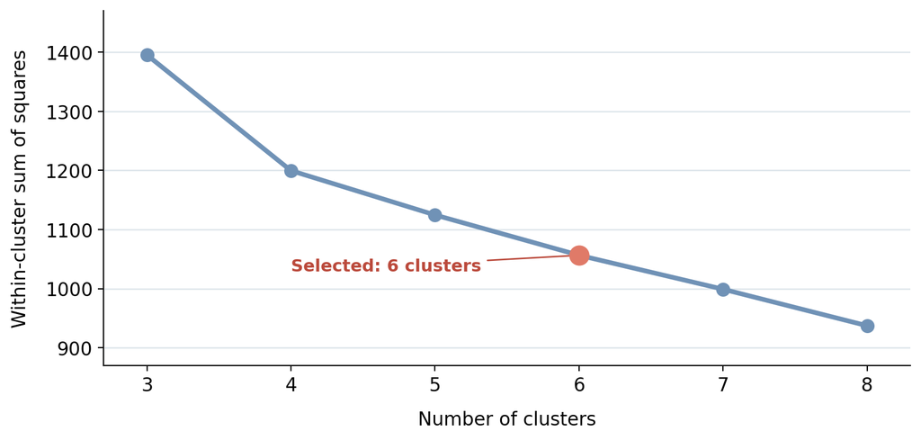

**Selected candidate: six clusters**

- **5 cuts** to the minimum spanning tree.
- **WSS:** 1,056.38.
- **Smallest cluster:** 13 townships.
- **Largest cluster:** 88 townships, compared with 167 under five clusters.

**Methodological note**

There is no clear WSS elbow. Six groups balance within-cluster similarity, cluster size and geographic interpretability.

## 8. SKATER — Connected Regional Groups

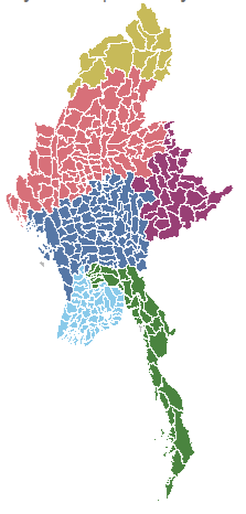

**Cluster sizes**

| Cluster | Townships |
| --- | --- |
| 1 | 88 |
| 2 | 82 |
| 3 | 36 |
| 4 | 13 |
| 5 | 29 |
| 6 | 79 |

The **327** clustered townships are contiguous within their assigned group. The three isolated townships are shown separately. Cluster labels are **not** severity rankings.

## 9. Temporal Profiles by SKATER Cluster

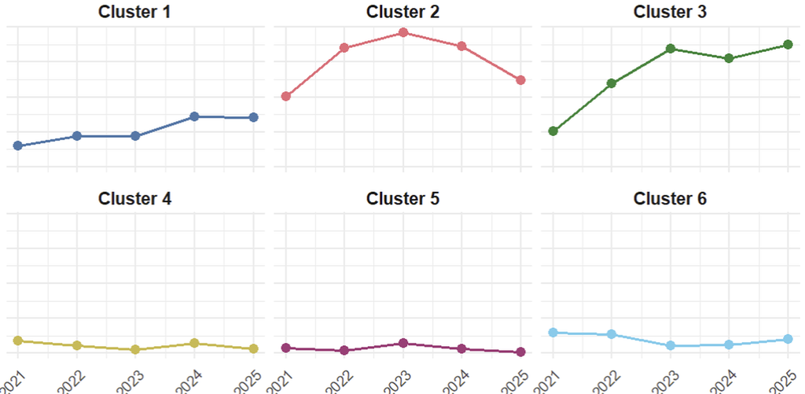

**Distinct trajectories:** Cluster 2 peaks in 2023 then declines; Cluster 3 rises strongly and rebounds in 2025; Clusters 4 and 5 remain comparatively low.

*Annual values are average monthly recorded events per township; 2025 covers January–September only. Descriptive patterns are not trend significance tests.*

## 10. Integrated Insights, Applications and Limits

**Where to investigate**

**23 of 27** Gi* hot spots are in Cluster 2. Cluster 5 contains **21 of 32** Gi* cold spots (21/29 of its townships).

**Why time is essential**

**17 of 27** full-period Gi* hot spots are EHSA sporadic coldspots. Overall concentration is not the same as monthly persistence.

**How regions differ**

SKATER groups neighbouring townships with similar historical frequency patterns, supporting regional monitoring perspectives.

**Limits:** historical records are not current safety estimates. Event counts are not severity; reporting and location uncertainty remain; 2025 has only nine months; descriptive patterns are not causal explanations.

**Sources:** ACLED conflict events and codebook; MIMU township boundaries; Su Mon (ACLED, 2024); CFR Global Conflict Tracker; *R for Geospatial Data Science and Analytics*, Chs. 10–12. Complete APA references, code and AI disclosure are included in the Technical Report.

## 11. References

For complete data preparation, methodology, diagnostics, code and interpretation: View the full [Technical Report](https://isss-626-course.vercel.app/take-home_exercise/take-home_ex2_tr.html)